# Keras Example : Subtype Classification

Jae Kwan Koo

## Library

```r
library(data.table)
library(tidyverse)

library(caret)
library(keras)
library(tensorflow)
```

## Install Keras in r (windows)

**Keras는 Python으로 구현된 쉽고 간결한 딥러닝 라이브러리이다.**

[케라스 이야기 - 깃헙 블로그](https://tykimos.github.io/2017/01/27/Keras_Talk/)

먼저 **Anaconda**를 설치하고, `devtools::install_github("rstudio/keras")`를 통해 keras를 설치한다.  
tensorflow역시 마찬가지이다. `devtools::install_github("rstudio/tensorflow")`

이후, library(keras), library(tensorflow)불러온뒤, `install_tensorflow()`를 통해 설치하면 끝이 난다.

꽤 쉬운 설치방법이라 생각했지만, error를 마주치게 된다면 여기서 밑의 방법을 써보자.  
며칠을 고생한 뒤 에러가 나지 않는 방법으로 설치를 성공했다.

박찬엽님의 블로그 글을 참조했다.  
[(conda4r) R을 위해서 conda를 설치해보자](https://mrchypark.github.io/post/conda4r-r%EC%9D%84-%EC%9C%84%ED%95%B4%EC%84%9C-conda%EB%A5%BC-%EC%84%A4%EC%B9%98%ED%95%B4%EB%B3%B4%EC%9E%90/)

### My method

```r
remotes::install_github("mrchypark/multilinguer")
multilinguer::install_conda()


install.packages("reticulate")
reticulate::install_miniconda()
library(reticulate)



library(multilinguer)
# has_conda()

remotes::install_github("haven-jeon/KoSpacing")
devtools::install_github("nathan-russell/hashmap")
```

KoSpacing을 하기 위한 작업이다.(이 패키지에 대한 소개는 블로그를 참조)  
혹시 대비해서 Anaconda Navigator에서도 Rstudio를 설치했다.

```r
library(KoSpacing)
library(reticulate)
packageVersion("KoSpacing")



KoSpacing::set_env()

spacing("김형호영화시장분석가는'1987'의네이버영화정보네티즌10점평에서언급된단어들을지난해12월27일부터올해1월10일까지통계프로그램R과KoNLP패키지로텍스트마이닝하여분석했다.")


# install_tensorflow()

# reticulate::conda_version()
# reticulate::conda_list()
```

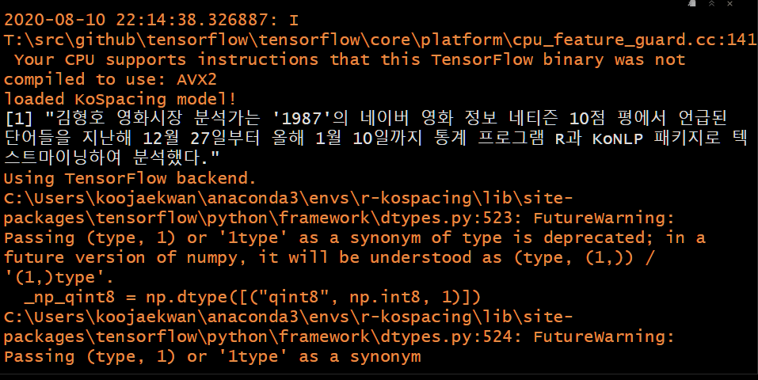

나도 모르게 곧바로 set_env()를 실행하고 진행하면 에러가 나서, 띄워쓰기 함수를 한번 실행했어야 했다.(아마 keras, tensorflow를 백앤드로 사용한 것이라고 이해하고 있다.)  
set_env()를 통해 환경세팅을 해준뒤, keras패키지의 함수들은 정상적으로 돌아갔다.(나의 경우)

결론적으로 설치가 완료되었다.(안정적인 방법은 더 찾고 있다)  
MNIST를 불러오면서 확인을 함과 동시에 example을 진행해보면 좋을 것이다.

밑의 예제는 유방암의 4가지 아형분류에 대한 예제를 keras를 이용하여 진행해보려고 한다.

## Data

```r
data <- fread("mrna.csv", data.table = F)
meta_dat <- fread("meta_dat.csv", header = T,data.table = F)


rownames(data) <- data$V1
data$V1 <- NULL
rownames(meta_dat) <- meta_dat$V1
meta_dat$V1 <- NULL
```

물론 tibble::rownames_to_columns()함수도 유용하게 사용될 수 있다.

```r
data_mat <- as.matrix(data)

dimnames(data_mat) <- NULL
```

## Data Partition

```r
set.seed(100)

index <- createDataPartition(1:630, p = 0.8, list = F)

train_x <- data_mat[index,]
train_y <- meta_dat[index,]

test_x <- data_mat[-index,]
test_y <- meta_dat[-index,]
```

seed를 박아서 재현성을 유지한다.

```r
train_x %>% class; train_y %>% class
test_x %>% class; test_y %>% class
```

## One-hot encoding

```r
# HER2 Luminal A LuminalB TNBC
as.numeric(as.factor(train_y))[1:20]



# One-hot encoding : training labels
train_y_labels <- to_categorical(as.numeric(as.factor(train_y))-1)

# One-hot encoding : validation labels
test_y_labels <- to_categorical(as.numeric(as.factor(test_y))-1)


train_y_labels %>% head
test_y_labels %>% head
```

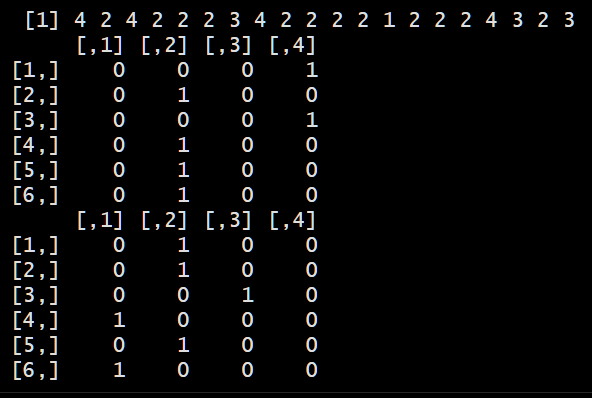

0아니면 1으로 만들어주기 위해 -1을 한다.

## Model

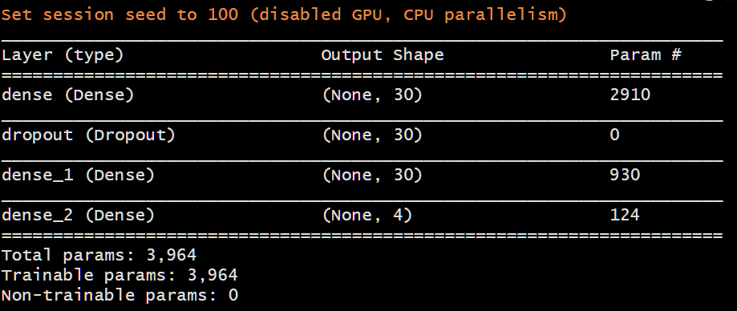

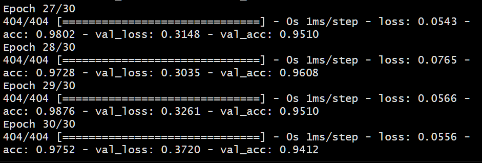

```r
use_session_with_seed(100)

# initial model
model <- keras_model_sequential()


# add the layer

# 96 inputs(independent var) -> [30 hidden nodes] ->
# [[30 hidden nodes]] -> 4 outputs

model %>%
  layer_dense(units = 30, activation = 'relu', input_shape = c(96)) %>%
  layer_dropout(rate = 0.5) %>%
  layer_dense(units = 30, activation = 'relu') %>%
  layer_dense(units = 4, activation = 'softmax')



# inspect the model
summary(model)


# compile the model
model %>% compile(
  loss = 'categorical_crossentropy',
  optimizer = 'adam',
  metrics = 'accuracy'
)



history <- model %>% fit(
  train_x,
  train_y_labels,
  epochs = 30,
  batch_size = 2,
  validation_split = 0.2
)
```

모델의 정보, 훈련과정을 확인가능하다. 훈련과정 일부만 사진으로 들고왔다.  
input shape에서 96은 투입되는 feature갯수를 의미한다.  
첫번째 hidden layer에 node는 30개, 두번째 hidden layer에 node도 30개로 설정했다.  
relu함수와 drop out에 대해서는 링크를 참조하자.

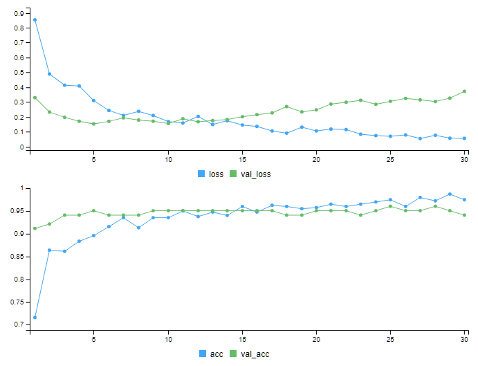

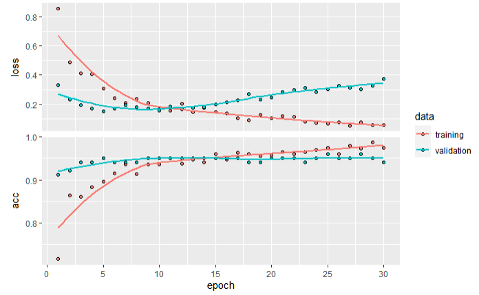

```r
plot(history)
```

어느 epoch시점부터 과적합이 일어나고 있다.  
과적합의 조짐이 일어나기 전에 훈련을 stop 하는방법 등을 더 찾아봐야겠다.

## Evaluation

```r
model %>% evaluate(test_x, test_y_labels)

model %>% predict_classes(test_x)




table(prediction = model %>% predict_classes(test_x),
      actual = as.numeric(as.factor(test_y))-1)
```

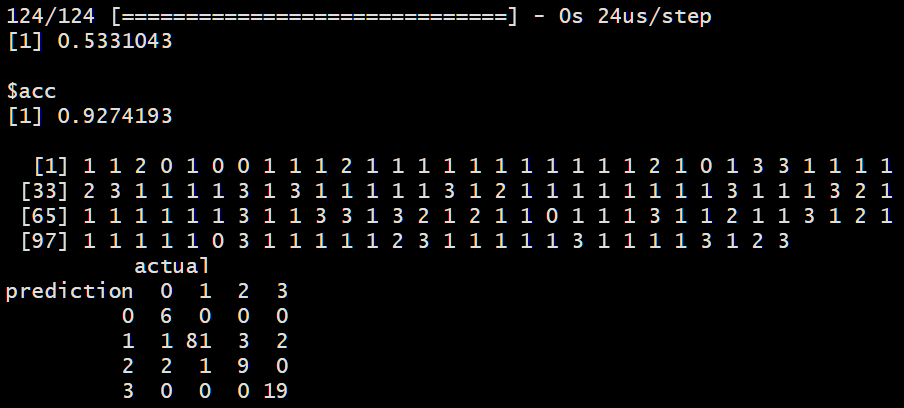

유방암 subtype을 분류하는 이전에 적합했던 기계학습 모형(Random Forest)과 비교해서 확인해볼 수 있다.

다음에는 더 이해할 수 있는 공부를 해볼예정이다.

## Reference

[dropout - Dive into Deep Learning (책)](https://ko.d2l.ai/chapter_deep-learning-basics/dropout.html)

[Relu - tstory blog](https://pythonkim.tistory.com/40)  
[신경망이란 무엇인가? - 3Blue1Brown](https://www.youtube.com/watch?v=aircAruvnKk)

[optimizor - tstory blog](https://nittaku.tistory.com/271)

[배치사이즈와 에포크](https://tykimos.github.io/2017/03/25/Fit_Talk/)  
[keras : Deep Learning in R (DataCamp)](https://www.datacamp.com/community/tutorials/keras-r-deep-learning)  
[Binary Classification using Keras in R](https://heartbeat.fritz.ai/binary-classification-using-keras-in-r-ef3d42202aaa)